# Exact test of goodness-of-fit

```r
#install.packages("XNomial")
#install.packages("pwr")
#install.packages("BSDA")

library(XNomial)
library(pwr)
library(BSDA)
```

# 1 Introduction

*When is it used?*

It is used when we have **one nominal variable and when we want to see whether the number of observations in each category fits a theoretical expectation and the sample size is small**.

The main goal is to answer the question: **“What is the probability of getting a result like my observed data?”**

The most common use is a nominal variable with only two values (test may be called the exact binominal test).

We compare the observed data with expected data. If the total number of observations is too hight (around a thousand), then we would rather use G-test or chi-square test of goodness-of-fit. When the nominal variable has more than two values, we can do multinomial tests of goodness-of-fit. The basic concepts are the same as for the exact binomial test.

*$H_0$ hypothesis*

- For a **two-tailed test**, the null hypothesis is that the number of observations in each category is **equal** to that predicted and the alternative hypothesis is that the boserved data are different from the expected.
- For a **one-tailed test**, the null hypothesis is that the observed number for one category is **equal to or less** than the expected and the alternative hypothesis is that the observed number in that category is greater than expected.

# 2 Scenario

Does my cat have a preference for one paw or uses both paws equally?

Expected values: He uses his paws equally 1:1

Data collection: He bats at the ribbon with his right paw 8 times and his left paw 2 times.

What is the probability of getting exactly 8 out of 10 right paws?

# 3 Application

Calculate the exact probability that my cat will use his left paw twice:

```r
# first number is whichever event there are fewer than expected of
# second number is the total number of trials
# third number is the expected proportion of whichever event there were fewer than expected of

# this is a probability of getting exactly 2 left paws and 8 right paws

dbinom(2,10,0.5) # Probability of single event only! Not binomial test!
```

```
## [1] 0.04394531
```

Calculate the exact probability that my cat will use his left paw twice or less:

```r
pbinom(2,10,0.5)
```

```
## [1] 0.0546875
```

```r
# Calculates the sum of the probabilities of the observed number and it gives the total probability of getting 2,1, or 0 uses of the left paw out of 10.
```

Probability that my cat will use his left paw twice or less OR his right paw twice or less (both extremes):

```r
# Adding the probability of getting 2,1, or 0 uses of the right paw, to account for both tails of the probability distribution; two-tailed test

# H0: The number of uses of the right paw is equal to the number of uses of the left paw
# H1: Thu number of uses of the left paw is not equal to the number of uses of the right paw

binom.test(2,10,0.5, alternative="two.sided", conf.level=0.95)
```

```
##
##  Exact binomial test
##
## data:  2 and 10
## number of successes = 2, number of trials = 10, p-value = 0.1094
## alternative hypothesis: true probability of success is not equal to 0.5
## 95 percent confidence interval:
##  0.02521073 0.55609546
## sample estimates:
## probability of success
##                    0.2
```

```r
# not significant
```

One-tailed test:

```r
#H0: There is 0.5 or more uses of the left paw
#H1: There is 0.5 or less uses of the left paw

binom.test(2,10,0.5, alternative="less", conf.level=0.95)
```

```
##
##  Exact binomial test
##
## data:  2 and 10
## number of successes = 2, number of trials = 10, p-value = 0.05469
## alternative hypothesis: true probability of success is less than 0.5
## 95 percent confidence interval:
##  0.0000000 0.5069013
## sample estimates:
## probability of success
##                    0.2
```

```r
# not significant
```

Probability density plot:

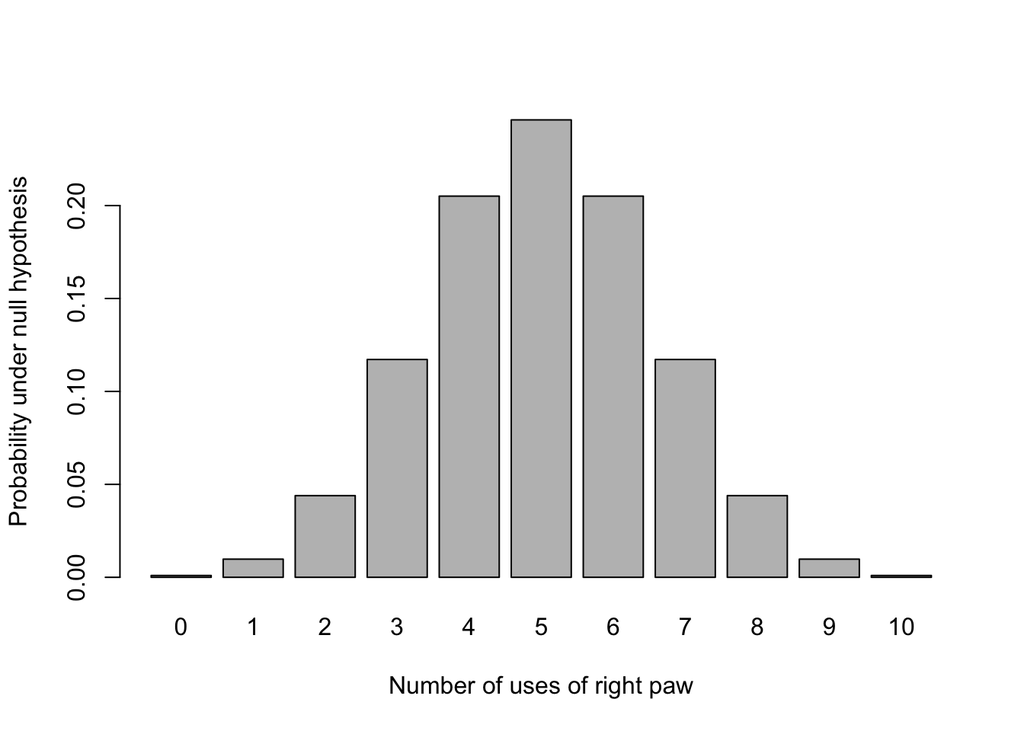

```r
# I can change the values for trials and prob
# I can change the values for xlab and ylab

trials = 10
prob = 0.5

x = seq(0, trials)
# x is a sequence, 1 to trials
y = dbinom(x, size=trials, p=prob)
# y is the vector of heights

barplot (height=y,
         names.arg=x,
         xlab="Number of uses of right paw",
         ylab="Probability under null hypothesis")
```